# How to calculate confidence intervals

Consider our snow vole case study… We will calculate the confidence intervals for the mean of the weight of the individuals, for the foot length, and for different groups.

```r
library(Rmisc)
library(Hmisc)
library(ggplot2)
library(boot)
```

```r
dati <- read.csv("data/captures.csv", sep=";")
```

# Calculating and plotting CIs with the traditional method

The function `CI` in the `Rmisc` package produces confidence intervals for the mean using the traditional method: si deve specificare la colonna di dati che vogliamo considerare

```r
CI(dati$weight_g, ci=0.95)
```

```
upper  mean lower
   NA    NA    NA
```

So what?? How can we fix that?? puliamo il dataset…NA va usato con cautela perchè in alcuni casi se non correttamente impostato ci cancellerebbe tutti i dati di tutte le colonne

```r
CI(na.omit(dati$weight_g), ci=0.95)
```

```
   upper     mean    lower
31.37342 29.83193 28.29044
```

What about the CIs for different group of animals? la tilde vuol dire “tenendo conto del sesso degli animali”

```r
dati2 <- na.omit(dati)
group.CI(weight_g ~ sex,
         data= dati2,
         ci=0.95)
```

| sex | weight_g.upper | weight_g.mean | weight_g.lower |
| --- | --- | --- | --- |
| F | 38.06126 | 33.72727 | 29.39329 |
| M | 34.41998 | 31.84615 | 29.27233 |

```r
intervalli <- group.CI(weight_g ~ sex,
         data= dati2,
         ci=0.95)
intervalli
```

| sex | weight_g.upper | weight_g.mean | weight_g.lower |
| --- | --- | --- | --- |
| F | 38.06126 | 33.72727 | 29.39329 |
| M | 34.41998 | 31.84615 | 29.27233 |

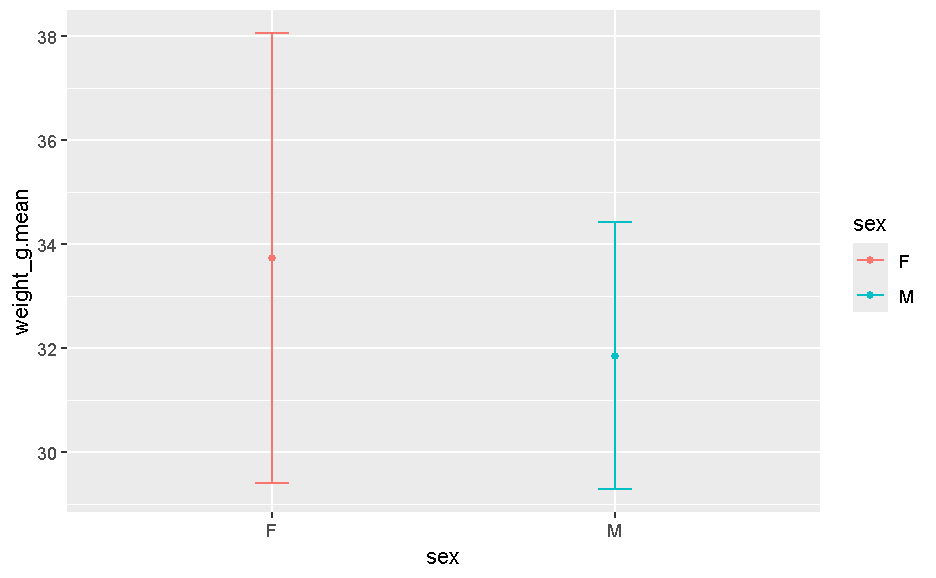

```r
ggplot(intervalli, aes(x=sex, y=weight_g.mean, colour=sex)) +
    geom_errorbar(aes(ymin=weight_g.lower, ymax=weight_g.upper), width=.1) +
    geom_line() +
    geom_point()
```

Do it on your own:

- plot just one of the confidence intervals (for males or for females, of for the overall mean)
- plot the confidence intervals for the mean weights, grouped for age
- repeat for the footlength

```r
as.data.frame(CI(na.omit(dati$weight_g), ci=0.95)) -> CImean
CImean
```

|  | CI(na.omit(dati$weight_g), ci = 0.95) |
| --- | --- |
| upper | 31.37342 |
| mean | 29.83193 |
| lower | 28.29044 |

Footlength CI:

```r
variabile <- dati2$footlength_mm # o qualsiasi altra variabile numerica

# script 'generalizzato'
intervalli <- group.CI(variabile ~ sex,
         data= dati2,
         ci=0.95)
intervalli
```

| sex | variabile.upper | variabile.mean | variabile.lower |
| --- | --- | --- | --- |
| F | 18.29347 | 18.09091 | 17.88835 |
| M | 20.09068 | 19.92308 | 19.75548 |

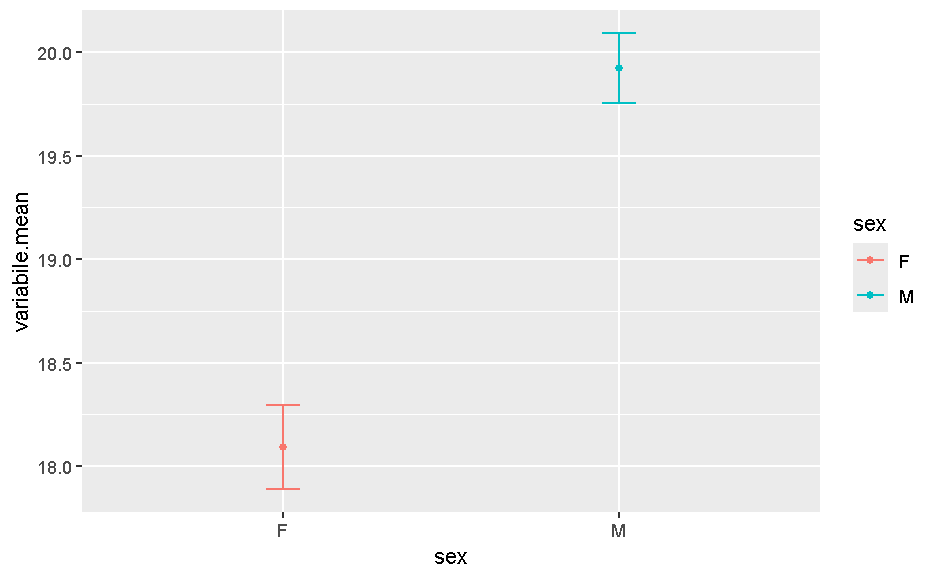

```r
ggplot(intervalli, aes(x=sex, y=variabile.mean, colour=sex)) +
    geom_errorbar(aes(ymin=variabile.lower, ymax=variabile.upper), width=.1) +
    geom_line() +
    geom_point()
```

# Calculating and plotting CIs with the bootstrapping method

We first need to apply the bootstrap to our data. For this purpose, we use the function `boot` in the `boot` package:

```r
boot.data <- boot(dati2$weight_g,
                  function(x,i) mean(x[i]),
                  R=10000)
```

R=10000 è il numero di repliche di campionamento. Now we can use the bootstrapped data to calculate the CIs, using the `boot.ci` function:

```r
boot.ci(boot.data,
        conf = 0.95)
```

```
BOOTSTRAP CONFIDENCE INTERVAL CALCULATIONS
Based on 10000 bootstrap replicates

CALL :
boot.ci(boot.out = boot.data, conf = 0.95)

Intervals :
Level      Normal              Basic
95%   (30.60, 34.79 )   (30.63, 34.79 )

Level     Percentile            BCa
95%   (30.62, 34.79 )   (30.54, 34.71 )
Calculations and Intervals on Original Scale
```

The function generates different types of non-parametric confidence intervals. For routine use, it is recommended to use the BCa or percentile methods. The formulae on which the calculations are based can be found in Chapter 5 of Davison and Hinkley (1997). Davison, A.C. and Hinkley, D.V. (1997) Bootstrap Methods and Their Application, Chapter 5. Cambridge University Press.

Do it on your own:

- Calculate the bootstrapped intervals for the sex groups
- Plot the bootstrapped intervals

adesso possiamo calcolare gli intervalli di bootstrap separatamente per i maschi e per le femmine

```r
library(tidyverse)
dati2 %>%
  filter(sex == "F") -> datiF
dati2 %>%
  filter(sex == "M") -> datiM

dataset <- datiM

boot.data <- boot(dataset$weight_g,
                  function(x,i) mean(x[i]),
                  R=10000)
boot.ci(boot.data,
        conf = 0.95)
```

```
BOOTSTRAP CONFIDENCE INTERVAL CALCULATIONS
Based on 10000 bootstrap replicates

CALL :
boot.ci(boot.out = boot.data, conf = 0.95)

Intervals :
Level      Normal              Basic
95%   (29.63, 34.02 )   (29.62, 34.00 )

Level     Percentile            BCa
95%   (29.69, 34.08 )   (29.62, 34.00 )
Calculations and Intervals on Original Scale
```

## Optional readings:

- ‘Calculating the Confidence interval for a mean using a formula’ from Statistics Learning Center. (Dr. Nic). 2013. www.youtube.com/watch?v=s4SRdaTycaw
- Davison, A.C. and Hinkley, D.V. (1997) Bootstrap Methods and Their Application, Chapter 5. Cambridge University Press.